# IODS course project

Let’s study the correlation values and pairwise scatterplots of these pairs showing highest positive or negative correlations.

```r
#Positive correlation
#correlation matrix values and scatterplots for the most correlating variable pairs with positive correlation

#rad & tax
cor_matrix["rad","tax"]
```

```
## [1] 0.91
```

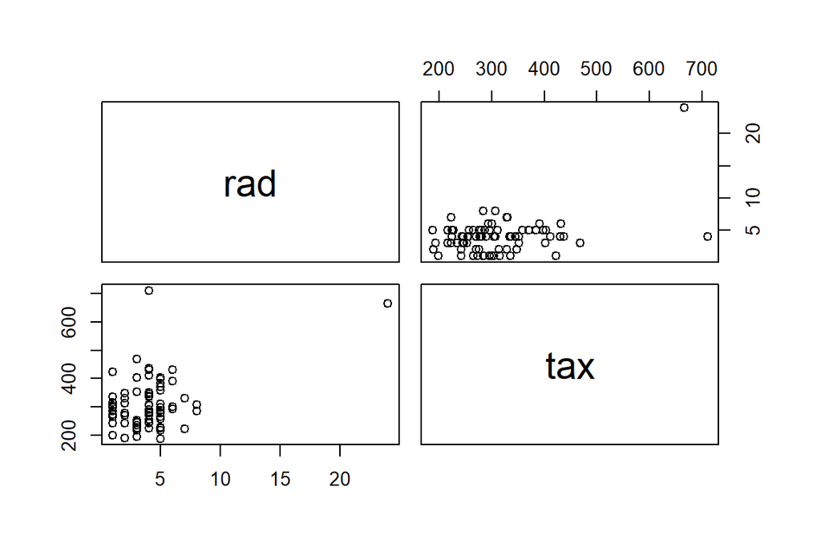

```r
pairs(Boston[,c("rad","tax")])
```

```r
#zn and dis
cor_matrix["zn","dis"]
```

```
## [1] 0.66
```

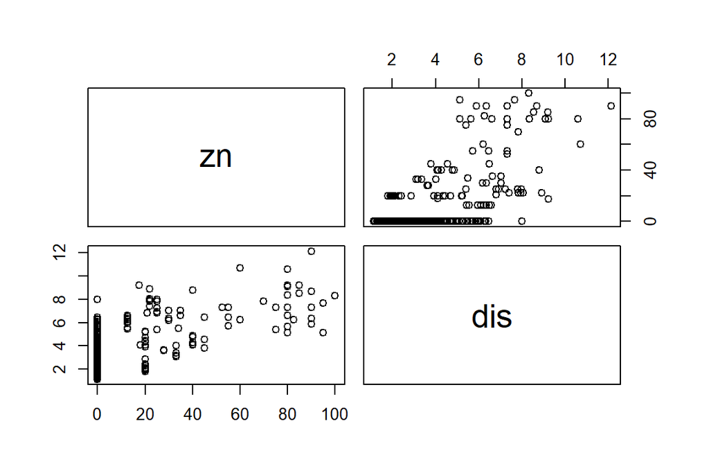

```r
pairs(Boston[,c("zn","dis")])
```

```r
#indus and nox
cor_matrix["indus","nox"]
```

```
## [1] 0.76
```

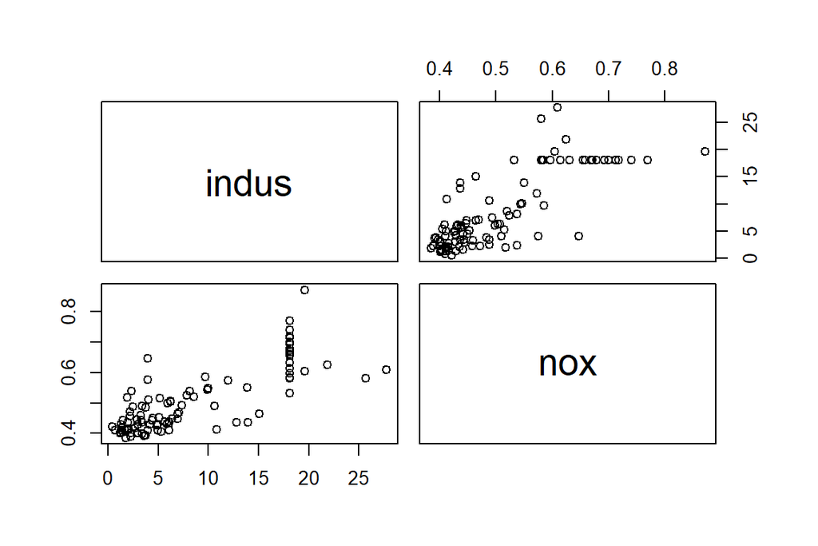

```r
pairs(Boston[,c("indus","nox")])
```

```r
#nox and age
cor_matrix["nox","age"]
```

```
## [1] 0.73
```

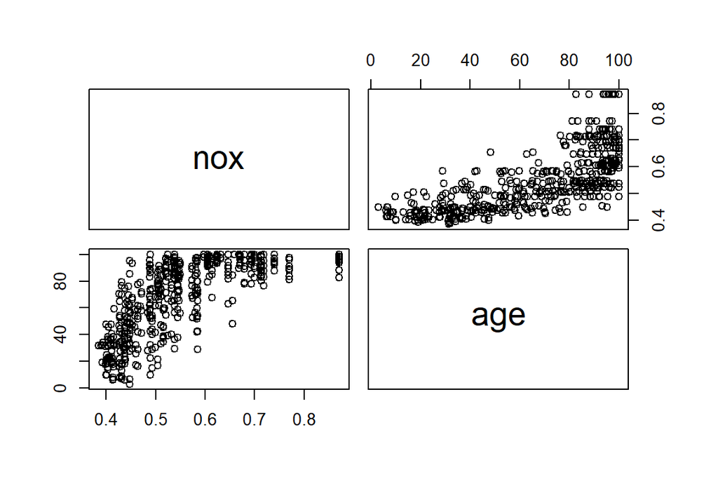

```r
pairs(Boston[,c("nox","age")])
```

```r
#nox and tax
cor_matrix["nox","tax"]
```

```
## [1] 0.67
```

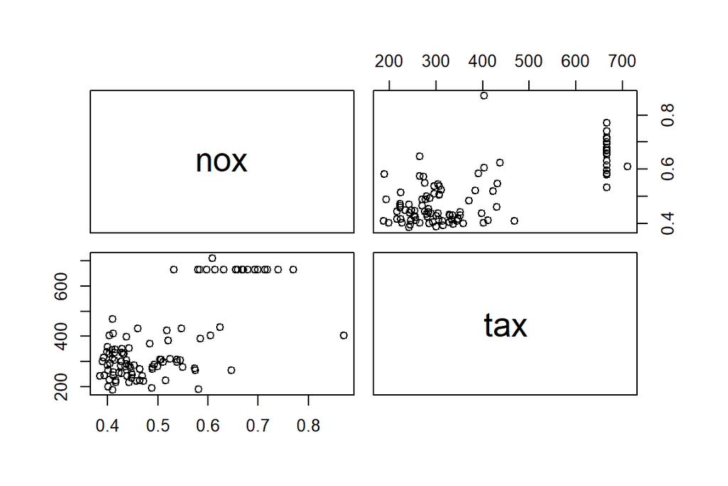

```r
pairs(Boston[,c("nox","tax")])
```

```r
#rm and medv
cor_matrix["rm","medv"]
```

```
## [1] 0.7
```

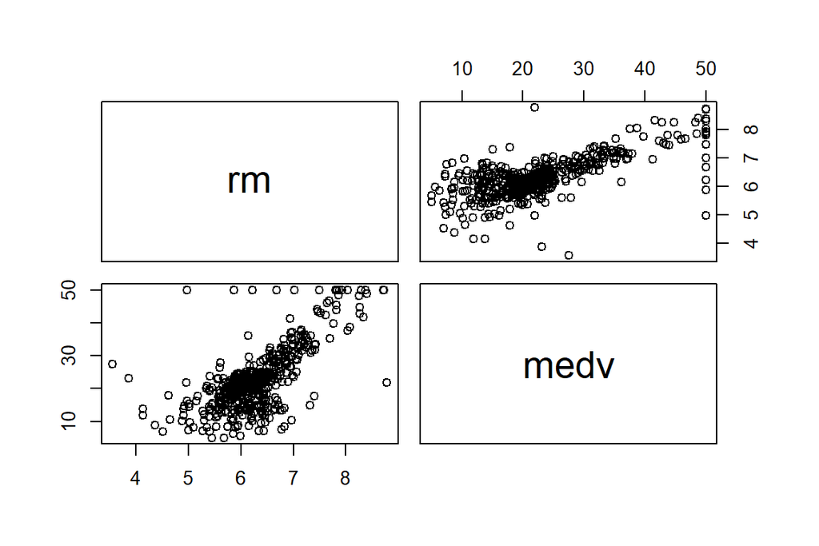

```r
pairs(Boston[,c("rm","medv")])
```

Interpretation of the positively correlated pairs: All the correlation values are at least 0.66 and the highest correlation value is 0.91. Next I interpret the correlation results of couple of pairs with the highest correlation values: The highest correlation is observed between rad and tax, on the other words, between ‘index of accessibility to radial highways’ and ‘full-value property-tax rate per $10,000’ which makes sense to me, since good access to highway could mean good location, which could increase the property-tax rate. The second highest pairwise correlation value of 0.76 is observed between indus and nox, or ‘proportion of non-retail business acres per town’ and ‘nitrogen oxides concentration (parts per 10 million)’. This also seems logical as more non-retail business could mean more traffic with motor vehicles on the area.

```r
#Clearest negative correlations: lstat and medv, age and dis, nox and dis, and indus and dis
#lstat & medv
cor_matrix["lstat","medv"]
```

```
## [1] -0.74
```

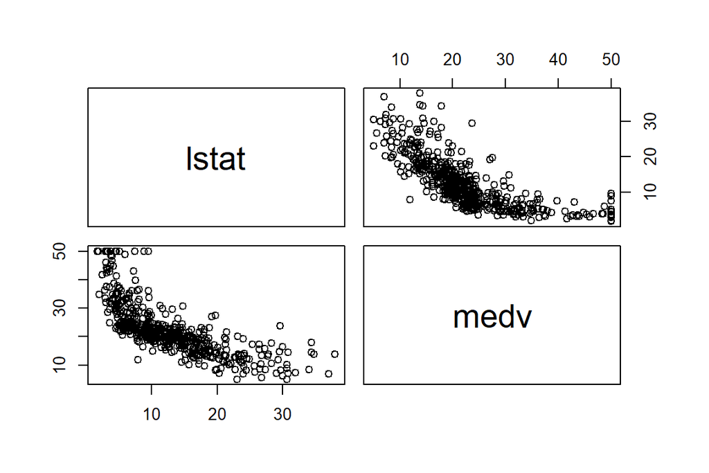

```r
pairs(Boston[,c("lstat","medv")])
```

```r
#age and dis
cor_matrix["age","dis"]
```

```
## [1] -0.75
```

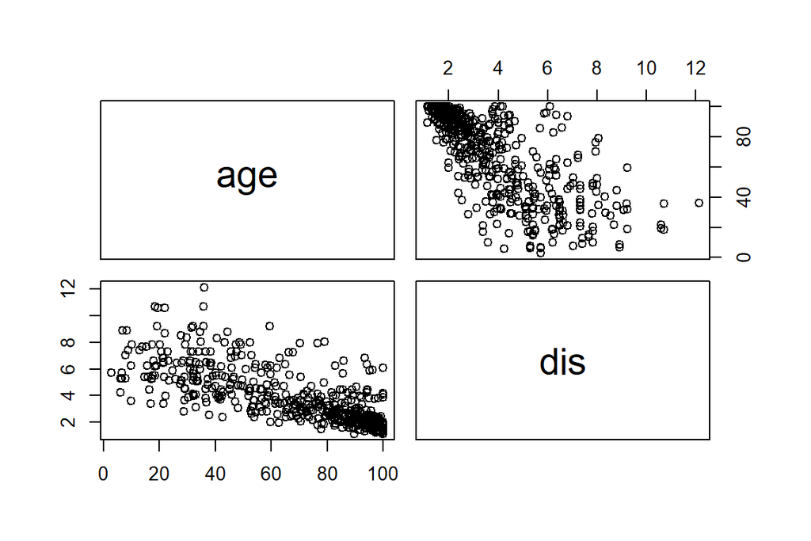

```r
pairs(Boston[,c("age","dis")])
```

```r
#nox and dis
cor_matrix["nox","dis"]
```

```
## [1] -0.77
```

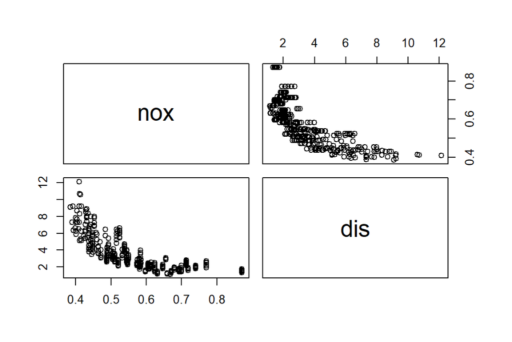

```r
pairs(Boston[,c("nox","dis")])
```

```r
#indus and dis
cor_matrix["indus","dis"]
```

```
## [1] -0.71
```

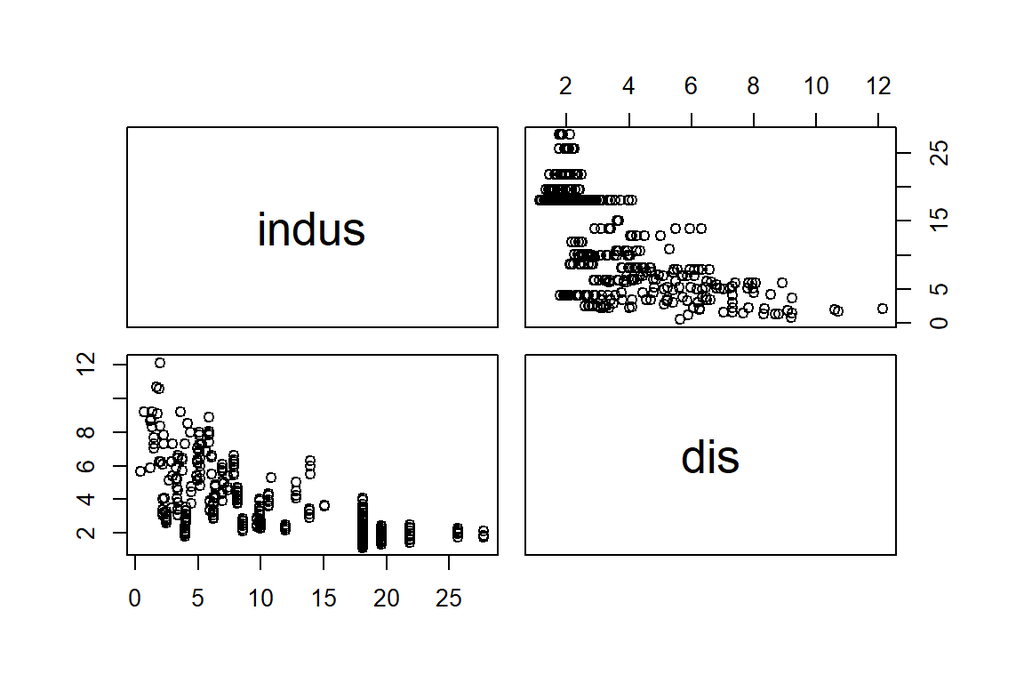

```r
pairs(Boston[,c("indus","dis")])
```

Interpretation of negatively correlated pairs: The values are all between -0.8 and -0.7. All the correlation plots show the negative correlation patter of the values: when one value increases the other value decreases. When thinking about the pairs and if the negative correlations make sense, it seems reasonable that when percent of population with lower status increases (I assume that “lower status” is somehow related to wealth of people, but it is not described clearly in the documentation of the data) the median value of owner-occupied homes decreases and vice versa. Age of the owner-occupied buldings seems to increase when distance to employment centres decreases. I think it makes sense that the oldest houses, or the houses that were built first, are located nearby the employment centres. Nox and dis: when the distance to employment centres increses, air pollutation decreases, since there may be much less traffic outside the employment centres, seems reasonable to me. Negative correlation between the distance of employment centres and ‘proportion of non-retail business acres per town’, in turn, do not seem that obvious to me, but maybe those places are located in different places in Boston.

## 4. Standardizing the data, modifying some variables and dividing the data to training and test sets

### Standardize data

```r
#standardize the data with scale function
boston_scaled <- as.data.frame(scale(Boston))

# summaries of the scaled variables
summary(boston_scaled)
```

```
##       crim                 zn               indus              chas
##  Min.   :-0.419367   Min.   :-0.48724   Min.   :-1.5563   Min.   :-0.2723
##  1st Qu.:-0.410563   1st Qu.:-0.48724   1st Qu.:-0.8668   1st Qu.:-0.2723
##  Median :-0.390280   Median :-0.48724   Median :-0.2109   Median :-0.2723
##  Mean   : 0.000000   Mean   : 0.00000   Mean   : 0.0000   Mean   : 0.0000
##  3rd Qu.: 0.007389   3rd Qu.: 0.04872   3rd Qu.: 1.0150   3rd Qu.:-0.2723
##  Max.   : 9.924110   Max.   : 3.80047   Max.   : 2.4202   Max.   : 3.6648
##       nox                rm               age               dis
##  Min.   :-1.4644   Min.   :-3.8764   Min.   :-2.3331   Min.   :-1.2658
##  1st Qu.:-0.9121   1st Qu.:-0.5681   1st Qu.:-0.8366   1st Qu.:-0.8049
##  Median :-0.1441   Median :-0.1084   Median : 0.3171   Median :-0.2790
##  Mean   : 0.0000   Mean   : 0.0000   Mean   : 0.0000   Mean   : 0.0000
##  3rd Qu.: 0.5981   3rd Qu.: 0.4823   3rd Qu.: 0.9059   3rd Qu.: 0.6617
##  Max.   : 2.7296   Max.   : 3.5515   Max.   : 1.1164   Max.   : 3.9566
##       rad               tax             ptratio            black
##  Min.   :-0.9819   Min.   :-1.3127   Min.   :-2.7047   Min.   :-3.9033
##  1st Qu.:-0.6373   1st Qu.:-0.7668   1st Qu.:-0.4876   1st Qu.: 0.2049
##  Median :-0.5225   Median :-0.4642   Median : 0.2746   Median : 0.3808
##  Mean   : 0.0000   Mean   : 0.0000   Mean   : 0.0000   Mean   : 0.0000
##  3rd Qu.: 1.6596   3rd Qu.: 1.5294   3rd Qu.: 0.8058   3rd Qu.: 0.4332
##  Max.   : 1.6596   Max.   : 1.7964   Max.   : 1.6372   Max.   : 0.4406
##      lstat              medv
##  Min.   :-1.5296   Min.   :-1.9063
##  1st Qu.:-0.7986   1st Qu.:-0.5989
##  Median :-0.1811   Median :-0.1449
##  Mean   : 0.0000   Mean   : 0.0000
##  3rd Qu.: 0.6024   3rd Qu.: 0.2683
##  Max.   : 3.5453   Max.   : 2.9865
```

Interpretation of standardization: When using scale function to standardization, the mean of variable is substracted from each value of the variable, and this sum is divided by standard deviation of the variables. As a result, all the variables are scaled so that their mean is zero.

```r
#categorical crime-variable
#quantiles of the variables represent the categories in the new crime-variable:
bins <- quantile(boston_scaled$crim)
bins
```

```
##           0%          25%          50%          75%         100%
## -0.419366929 -0.410563278 -0.390280295  0.007389247  9.924109610
```

```r
# create a categorical variable 'crime'
crime <- cut(boston_scaled$crim, breaks = bins, include.lowest = TRUE)

# look at the table of the new factor crime
table(crime)
```

```
## crime
## [-0.419,-0.411]  (-0.411,-0.39] (-0.39,0.00739]  (0.00739,9.92]
##             127             126             126             127
```

```r
#labels
crime <- cut(boston_scaled$crim, breaks = bins, include.lowest = TRUE, c("low", "med_low", "med_high", "high"))
table(crime)
```

```
## crime
##      low  med_low med_high     high
##      127      126      126      127
```

```r
# remove original crim from the dataset
boston_scaled <- dplyr::select(boston_scaled, -crim)

# add the new categorical value to scaled data
boston_scaled <- data.frame(boston_scaled, crime)
```

### Training and test sets

```r
#number of rows from which 80% and 20% sets are extracted
n <- nrow(boston_scaled)

# choose randomly 80% of the rows
#set seed to be able to get same results next time running this code
set.seed(34)
ind <- sample(n,  size = n * 0.8)

# create train set
train <- boston_scaled[ind,]

# create test set
test <- boston_scaled[-ind,]
```

## 5. Linear discriminant analysis and biplot

```r
# linear discriminant analysis
lda.fit <- lda(crime~., data = train)

# print the lda.fit object
lda.fit
```

```
## Call:
## lda(crime ~ ., data = train)
##
## Prior probabilities of groups:
##       low   med_low  med_high      high
## 0.2648515 0.2475248 0.2376238 0.2500000
##
## Group means:
##                   zn      indus        chas        nox         rm        age
## low       0.97719435 -0.9100174 -0.12514775 -0.8677755  0.4838136 -0.8548061
## med_low  -0.07926423 -0.3922070 -0.07547406 -0.5769537 -0.1157165 -0.3019980
## med_high -0.35146259  0.1723205  0.21980846  0.3591498  0.1234981  0.4078427
## high     -0.48724019  1.0171306 -0.07742312  1.0774249 -0.4390103  0.8243426
##                 dis        rad        tax    ptratio       black       lstat
## low       0.8796572 -0.6824111 -0.7285550 -0.4491365  0.37871316 -0.77089741
## med_low   0.4005805 -0.5374145 -0.5412289 -0.1074085  0.32726450 -0.15404758
## med_high -0.3668725 -0.4279751 -0.3299698 -0.3148233  0.06357068 -0.03397906
## high     -0.8459906  1.6379981  1.5139626  0.7806252 -0.77941196  0.88272177
##                 medv
## low       0.52219782
## med_low   0.01241626
## med_high  0.16371842
## high     -0.69846936
##
## Coefficients of linear discriminants:
##                  LD1         LD2         LD3
## zn       0.047418039  0.64669631 -0.98081239
## indus    0.058848364 -0.26592830  0.13957909
## chas    -0.101923092 -0.14489894 -0.03304474
## nox      0.368540630 -0.76051455 -1.24695787
## rm      -0.092980522 -0.05151109 -0.24910661
## age      0.278634665 -0.31401896 -0.03355529
## dis     -0.005313311 -0.25805772  0.24067257
## rad      3.215556870  1.10044728  0.26871801
## tax      0.231214252 -0.15273271  0.18508814
## ptratio  0.089767691  0.06682383 -0.28156875
## black   -0.090571321  0.03524218  0.14027864
## lstat    0.279557229 -0.22599218  0.41709558
## medv     0.252866942 -0.38507974 -0.07580231
##
## Proportion of trace:
##    LD1    LD2    LD3
## 0.9562 0.0331 0.0107
```

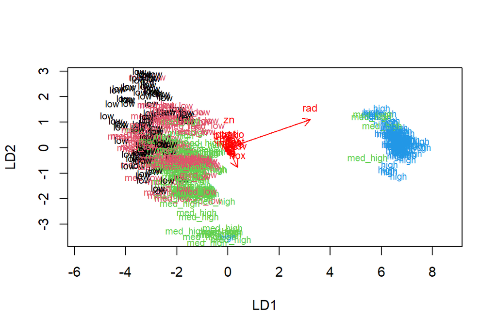

```r
# the function for lda biplot arrows
lda.arrows <- function(x, myscale = 1, arrow_heads = 0.1, color = "red", tex = 0.75, choices = c(1,2)){
  heads <- coef(x)
  graphics::arrows(x0 = 0, y0 = 0,
         x1 = myscale * heads[,choices[1]],
         y1 = myscale * heads[,choices[2]], col=color, length = arrow_heads)
  text(myscale * heads[,choices], labels = row.names(heads),
       cex = tex, col=color, pos=3)
}

# target classes as numeric
classes <- as.numeric(train$crime)

# plot the lda results (select both lines and execute them at the same time!)
plot(lda.fit, dimen = 2, col = classes, pch = classes)
lda.arrows(lda.fit, myscale = 1)
```

## 6. Prediction

```r
#removal of the crime variable from the test set
# save the correct classes from test data
correct_classes <- test$crime

# remove the crime variable from test data
test <- dplyr::select(test, -crime)

#predict the classes to test data:
lda.pred <- predict(lda.fit, newdata = test)

# cross tabulate the results
table(correct = correct_classes, predicted = lda.pred$class)
```

```
##           predicted
## correct    low med_low med_high high
##   low       12       8        0    0
##   med_low    5      15        6    0
##   med_high   0      12       16    2
##   high       0       0        0   26
```

Interpretation of prediction results (cross-tabulation of the results): From the result table I can deduce that the classifier most reliably predicts the high-category values of crime variable, since all the true high values are predicted correctly, and there are only two wrongly predicted values from the med_high category. Low-category values are not that well predicted as almost half of the true low-category values are predicted to be higher than they were, as 8/20 of true low values are predicted to be med_low values, and 5 of the med_low values are incorrectly predicted to be low values. The accuracy of the predictor is even weaker with the two intermediate classes, med_low and med_high. The prediction of these classes divided the values to three different categories. Fortunately, the category jumps of predictions were to the nearest two categories, no two-category jumps occurred.

## 7. Reload and scaling of Boston data, distance matrix calculation and k-means clustering analysis

```r
data("Boston")
scaled_boston = as.data.frame(scale(Boston))
# euclidean distance matrix is default method in dist function:
dist_eu <- dist(scaled_boston)

library(ggplot2)
set.seed(34)

#k-means algorithm, 1. run:
km4 <- kmeans(scaled_boston, centers = 4)

#how are the observations dividied into the four clusters?
table(km4$cluster)
```

```
##
##   1   2   3   4
## 127  42 212 125
```

[figure not shown]

```r
#cluster 2 seems to contain much less observations than others, clusters 1 and 4 are nearly same size and cluster 3 contains about two times that much observations as cluster 1 or 4.
#visualization of four-cluster results:
pairs(scaled_boston, col = km4$cluster, main = "Full data pairs")
```

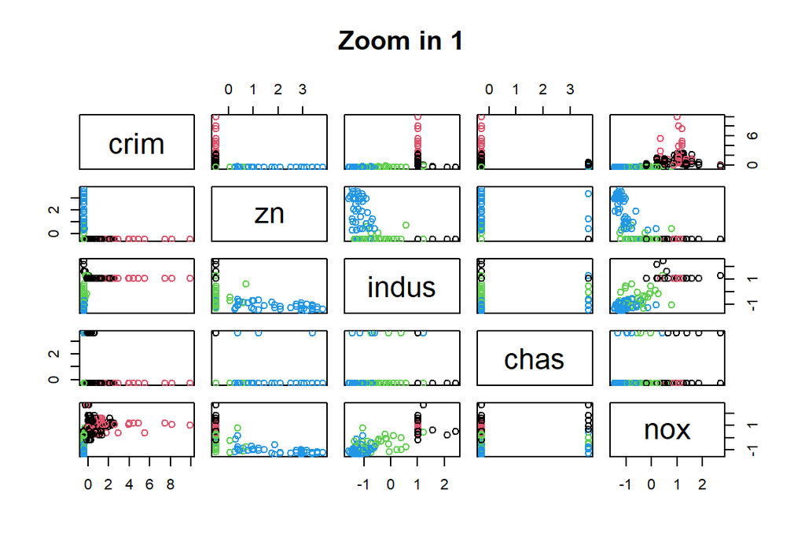

```r
pairs(scaled_boston[1:5], col = km4$cluster, main = "Zoom in 1")
```

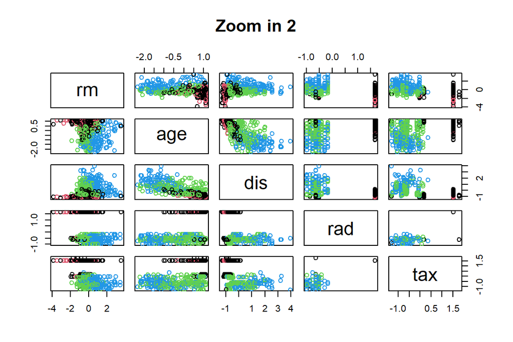

```r
pairs(scaled_boston[6:10], col = km4$cluster, main = "Zoom in 2")
```